# Creating Models: Linear Regression

Maximilian Weissenbacher

9 7 2021

# Create Models out of the obtained data

## The key goal of this project is to estimate the price of a car

In the “Data Cleaning & Understanding” markdown file all of the variables got observed.

The variables which might have an influence on the price are: - Kraftstoff (fuel type) - Marke (car make) - Hubraum (engine sizte; in strong Correlation to PS) - PS (horsepower) - KM (kilometers driven) - Alter (age of the car) - Fahrzeughalter (number of car owners)

```r
clean_cars <- read.csv("cleaned_cars1.csv")
```

## Create Train/Test Set

```r
all_cars <- clean_cars[complete.cases(clean_cars), ]
train.index <- createDataPartition(all_cars$preis, list = FALSE, p = 0.75)
train <- all_cars[train.index, ]
test <- all_cars[-train.index, ]
nrow(test)
```

```
## [1] 7839
```

```r
nrow(train)
```

```
## [1] 23520
```

## Create different models

```r
# Just test on clean_cars. When all data is scraped use Train/Test
md100 <- lm(preis~ps, data=train)
summary(md100)
```

```
##
## Call:
## lm(formula = preis ~ ps, data = train)
##
## Residuals:
##    Min     1Q Median     3Q    Max
## -86023  -5589    407   5100 359004
##
## Coefficients:
##              Estimate Std. Error t value Pr(>|t|)
## (Intercept) -9852.466    175.857  -56.02   <2e-16 ***
## ps            175.670      1.016  172.88   <2e-16 ***
## ---
## Signif. codes:  0 '***' 0.001 '**' 0.01 '*' 0.05 '.' 0.1 ' ' 1
##
## Residual standard error: 14020 on 23518 degrees of freedom
## Multiple R-squared:  0.5596, Adjusted R-squared:  0.5596
## F-statistic: 2.989e+04 on 1 and 23518 DF,  p-value: < 2.2e-16
```

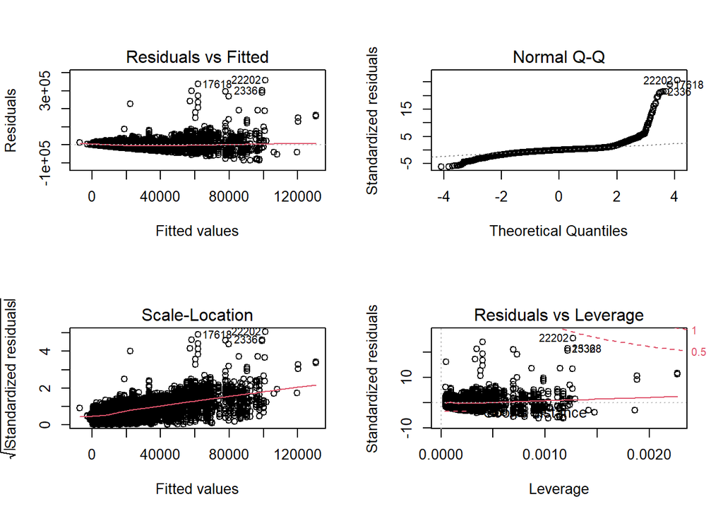

```r
par(mfrow=c(2,2))
plot(md100)
```

```r
bptest(md100)
```

```
##
##  studentized Breusch-Pagan test
##
## data:  md100
## BP = 1261.8, df = 1, p-value < 2.2e-16
```

- The Residuals vs. Fitted Plot shows in this case that the model doesn’t have non-linear relationships.
- Normal QQ Plot: Normal distribution is not given because the points don’t follow the increasing line at the start and the tail
- Scale-Location Plot: residuals aren’t spread equally along the ranges of predictors, because the line is increasing and it should be horizontal in an optimal case

Now try a model with some additional variables:

```r
md0 <- lm(preis~Alter+ps+km+marke, data=train)
summary(md0)
```

```
##
## Call:
## lm(formula = preis ~ Alter + ps + km + marke, data = train)
##
## Residuals:
##    Min     1Q Median     3Q    Max
## -91861  -2938   -503   2281 371505
##
## Coefficients:
##                       Estimate Std. Error t value Pr(>|t|)
## (Intercept)          3.718e+03  5.772e+03   0.644  0.51947
## Alter               -6.451e+02  2.146e+01 -30.056  < 2e-16 ***
## ps                   1.356e+02  1.246e+00 108.777  < 2e-16 ***
## km                  -6.240e-02  1.424e-03 -43.818  < 2e-16 ***
## markeAlfa Romeo      2.421e+03  6.269e+03   0.386  0.69935
## markeAlpina          3.443e+04  1.290e+04   2.670  0.00760 **
## markeAston Martin    2.568e+04  8.816e+03   2.912  0.00359 **
## markeAudi            3.140e+03  5.772e+03   0.544  0.58647
## markeBentley        -3.298e+03  7.749e+03  -0.426  0.67039
## markeBMW             1.167e+03  5.772e+03   0.202  0.83980
## markeChevrolet      -3.661e+02  6.291e+03  -0.058  0.95360
## markeChrysler       -4.221e+02  6.932e+03  -0.061  0.95144
## markeCitroen         8.309e+02  5.780e+03   0.144  0.88568
## markeCorvette       -9.494e+03  1.290e+04  -0.736  0.46161
## markeCupra          -3.010e+03  8.157e+03  -0.369  0.71212
## markeDacia           4.363e+02  6.229e+03   0.070  0.94417
## markeDaewoo          5.280e+03  8.156e+03   0.647  0.51738
## markeDaihatsu        6.740e+03  6.659e+03   1.012  0.31151
## markeDodge          -1.279e+04  1.290e+04  -0.992  0.32141
## markeDS Automobiles -2.943e+02  1.289e+04  -0.023  0.98179
## markeFerrari         5.440e+04  7.455e+03   7.297 3.03e-13 ***
## markeFiat            2.098e+03  5.777e+03   0.363  0.71647
## markeFord            1.674e+03  5.776e+03   0.290  0.77201
## markeHonda           2.572e+03  6.292e+03   0.409  0.68272
## markeHUMMER          6.983e+02  1.289e+04   0.054  0.95681
## markeHyundai         2.872e+02  5.776e+03   0.050  0.96034
## markeJaguar          2.924e+03  6.449e+03   0.453  0.65026
## markeJeep           -4.152e+02  6.930e+03  -0.060  0.95223
## markeKia             9.484e+01  5.972e+03   0.016  0.98733
## markeLada           -6.291e+01  1.289e+04  -0.005  0.99611
```

[output cut: 17 more lines]

```
## markeSEAT            1.029e+03  5.773e+03   0.178  0.85855
## markeSkoda           1.850e+03  5.776e+03   0.320  0.74876
## markesmart           4.938e+03  5.985e+03   0.825  0.40927
## markeSsangYong      -5.994e+03  9.986e+03  -0.600  0.54837
## markeSubaru          1.278e+03  6.733e+03   0.190  0.84946
## markeSuzuki          7.447e+02  5.939e+03   0.125  0.90021
## markeToyota          2.979e+03  5.900e+03   0.505  0.61367
## markeVolkswagen      3.709e+03  5.771e+03   0.643  0.52037
## markeVolvo           6.164e+03  5.813e+03   1.060  0.28898
## ---
## Signif. codes:  0 '***' 0.001 '**' 0.01 '*' 0.05 '.' 0.1 ' ' 1
##
## Residual standard error: 11530 on 23464 degrees of freedom
## Multiple R-squared:  0.7027, Adjusted R-squared:  0.702
## F-statistic:  1008 on 55 and 23464 DF,  p-value: < 2.2e-16
```

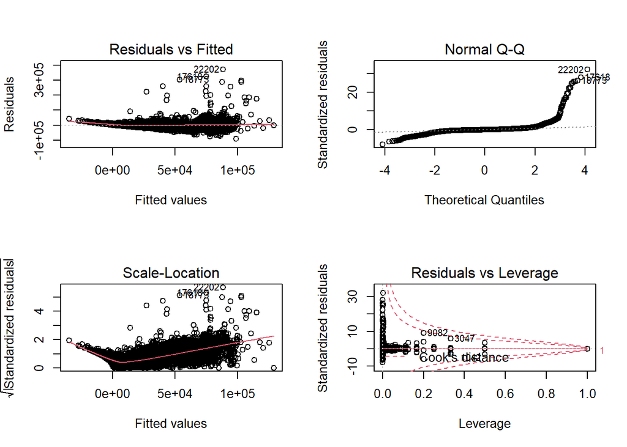

```r
par(mfrow=c(2,2))
plot(md0)
```

```r
data.frame(vif(md0))
```

```
##           GVIF Df GVIF..1..2.Df..
## Alter 1.922115  1        1.386404
## ps    2.222866  1        1.490928
## km    1.932204  1        1.390037
## marke 2.494720 52        1.008829
```

```r
#Test of Homoscedasticity
bptest(md0) # p smaller than 0,05 -> heteroscedasticity
```

```
##
##  studentized Breusch-Pagan test
##
## data:  md0
## BP = 1129, df = 55, p-value < 2.2e-16
```

The requirements are again not satisfied.

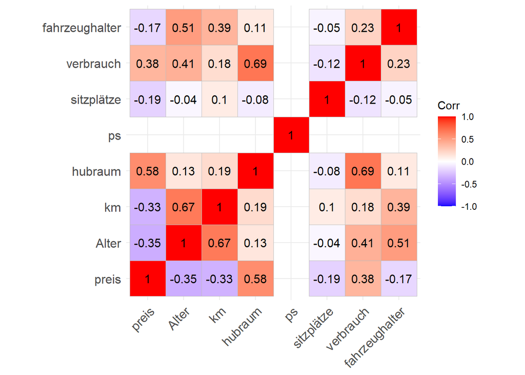

```r
clean_cars %>%
  select(preis, Alter, km, hubraum, ps, sitzplätze, verbrauch,fahrzeughalter) %>%
  cor() %>%
  ggcorrplot(lab=TRUE)
```

```r
# Involve Fahrzeughalter
frz <- clean_cars[complete.cases(clean_cars), ]
md1 <- lm(preis~Alter+ps+fahrzeughalter, data=train)
summary(md1)
```

```
##
## Call:
## lm(formula = preis ~ Alter + ps + fahrzeughalter, data = train)
##
## Residuals:
##    Min     1Q Median     3Q    Max
## -87239  -3985   -239   3050 360775
##
## Coefficients:
##                  Estimate Std. Error t value Pr(>|t|)
## (Intercept)     1463.6105   246.1881   5.945 2.80e-09 ***
## Alter          -1157.6134    19.8212 -58.403  < 2e-16 ***
## ps               169.2990     0.9248 183.064  < 2e-16 ***
## fahrzeughalter  -962.8099   124.9358  -7.706 1.34e-14 ***
## ---
## Signif. codes:  0 '***' 0.001 '**' 0.01 '*' 0.05 '.' 0.1 ' ' 1
##
## Residual standard error: 12670 on 23516 degrees of freedom
## Multiple R-squared:  0.6403, Adjusted R-squared:  0.6403
## F-statistic: 1.395e+04 on 3 and 23516 DF,  p-value: < 2.2e-16
```

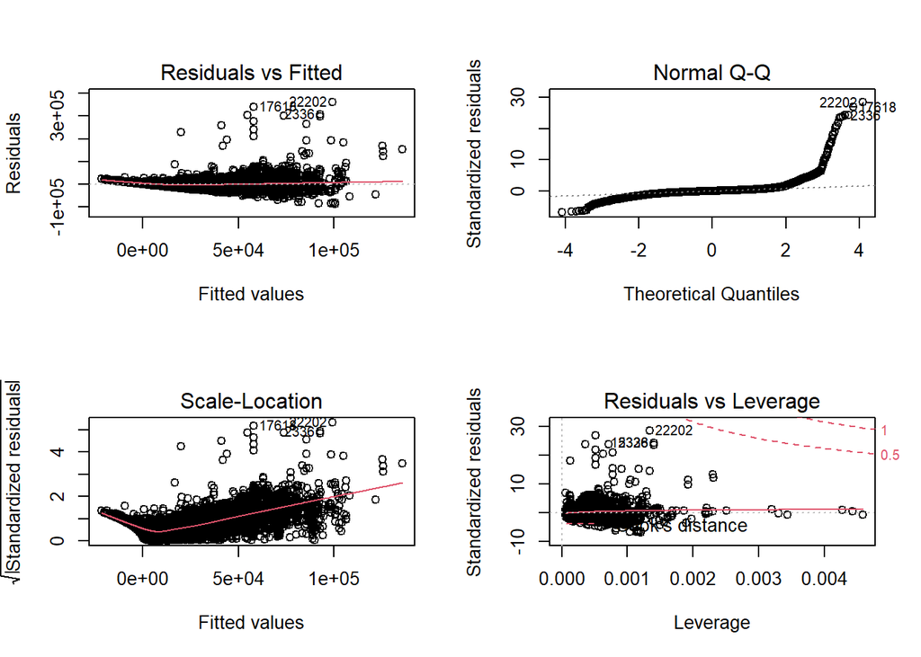

```r
par(mfrow=c(2,2))
plot(md1)
```

```r
# Model 2 with log10 on price, because price is right screwed
md2 <- lm(log10(preis)~Alter+ps+km+marke, data=train)
summary(md2)
```

```
##
## Call:
## lm(formula = log10(preis) ~ Alter + ps + km + marke, data = train)
##
## Residuals:
##      Min       1Q   Median       3Q      Max
## -1.47650 -0.06367  0.00406  0.07191  1.37310
##
## Coefficients:
##                       Estimate Std. Error  t value Pr(>|t|)
## (Intercept)          4.300e+00  7.226e-02   59.502  < 2e-16 ***
## Alter               -4.395e-02  2.687e-04 -163.582  < 2e-16 ***
## ps                   2.123e-03  1.560e-05  136.044  < 2e-16 ***
## km                  -1.247e-06  1.783e-08  -69.963  < 2e-16 ***
## markeAlfa Romeo     -3.475e-01  7.848e-02   -4.428 9.55e-06 ***
## markeAlpina          1.820e-01  1.614e-01    1.127 0.259645
## markeAston Martin    1.538e-01  1.104e-01    1.393 0.163486
## markeAudi           -5.567e-02  7.226e-02   -0.770 0.441074
## markeBentley        -5.764e-01  9.701e-02   -5.942 2.86e-09 ***
## markeBMW            -8.725e-02  7.226e-02   -1.207 0.227257
## markeChevrolet      -3.506e-01  7.876e-02   -4.451 8.57e-06 ***
## markeChrysler       -4.005e-01  8.678e-02   -4.615 3.95e-06 ***
## markeCitroen        -2.258e-01  7.236e-02   -3.120 0.001809 **
## markeCorvette        2.028e-01  1.614e-01    1.256 0.209091
## markeCupra          -3.252e-01  1.021e-01   -3.184 0.001453 **
## markeDacia          -2.888e-01  7.798e-02   -3.703 0.000213 ***
## markeDaewoo         -1.007e+00  1.021e-01   -9.863  < 2e-16 ***
## markeDaihatsu       -4.634e-01  8.337e-02   -5.559 2.75e-08 ***
## markeDodge          -1.726e-01  1.614e-01   -1.069 0.285143
## markeDS Automobiles -1.735e-01  1.614e-01   -1.075 0.282499
## markeFerrari         3.797e-01  9.333e-02    4.069 4.74e-05 ***
## markeFiat           -2.612e-01  7.233e-02   -3.611 0.000306 ***
## markeFord           -2.430e-01  7.232e-02   -3.360 0.000780 ***
## markeHonda          -1.309e-01  7.877e-02   -1.662 0.096563 .
## markeHUMMER          2.553e-01  1.614e-01    1.582 0.113737
## markeHyundai        -2.456e-01  7.231e-02   -3.396 0.000684 ***
## markeJaguar          1.737e-01  8.073e-02    2.151 0.031471 *
## markeJeep           -1.199e-02  8.676e-02   -0.138 0.890070
## markeKia            -2.173e-01  7.477e-02   -2.906 0.003668 **
## markeLada           -4.655e-01  1.614e-01   -2.884 0.003925 **
```

[output cut: 17 more lines]

```
## markeSEAT           -2.186e-01  7.227e-02   -3.025 0.002488 **
## markeSkoda          -1.978e-01  7.232e-02   -2.735 0.006250 **
## markesmart          -2.363e-01  7.492e-02   -3.154 0.001614 **
## markeSsangYong      -2.874e-01  1.250e-01   -2.298 0.021548 *
## markeSubaru         -8.813e-02  8.430e-02   -1.045 0.295815
## markeSuzuki         -2.764e-01  7.435e-02   -3.717 0.000202 ***
## markeToyota         -1.486e-01  7.387e-02   -2.012 0.044230 *
## markeVolkswagen     -1.332e-01  7.225e-02   -1.844 0.065251 .
## markeVolvo          -4.369e-02  7.278e-02   -0.600 0.548249
## ---
## Signif. codes:  0 '***' 0.001 '**' 0.01 '*' 0.05 '.' 0.1 ' ' 1
##
## Residual standard error: 0.1444 on 23464 degrees of freedom
## Multiple R-squared:  0.8821, Adjusted R-squared:  0.8818
## F-statistic:  3191 on 55 and 23464 DF,  p-value: < 2.2e-16
```

Here you can see a very good R2 value of 88%. But again the requirements aren’t satisfied.

```r
# Model 3 with polynomial regression
md3 <- lm(preis~poly(Alter,3)+poly(ps,3)+poly(km,3),train)
summary(md3)
```

```
##
## Call:
## lm(formula = preis ~ poly(Alter, 3) + poly(ps, 3) + poly(km,
##     3), data = train)
##
## Residuals:
##     Min      1Q  Median      3Q     Max
## -109694   -3445    -140    2884  330094
##
## Coefficients:
##                   Estimate Std. Error t value Pr(>|t|)
## (Intercept)       16119.56      75.63 213.149   <2e-16 ***
## poly(Alter, 3)1 -392038.46   18331.53 -21.386   <2e-16 ***
## poly(Alter, 3)2  131435.11   13696.04   9.597   <2e-16 ***
## poly(Alter, 3)3  -25595.39   12159.79  -2.105   0.0353 *
## poly(ps, 3)1    2345503.25   11693.43 200.583   <2e-16 ***
## poly(ps, 3)2     436559.32   11990.98  36.407   <2e-16 ***
## poly(ps, 3)3       9414.85   11849.50   0.795   0.4269
## poly(km, 3)1    -695476.72   17937.62 -38.772   <2e-16 ***
## poly(km, 3)2     268737.44   13753.09  19.540   <2e-16 ***
## poly(km, 3)3    -111079.79   12686.94  -8.755   <2e-16 ***
## ---
## Signif. codes:  0 '***' 0.001 '**' 0.01 '*' 0.05 '.' 0.1 ' ' 1
##
## Residual standard error: 11600 on 23510 degrees of freedom
## Multiple R-squared:  0.6987, Adjusted R-squared:  0.6985
## F-statistic:  6056 on 9 and 23510 DF,  p-value: < 2.2e-16
```

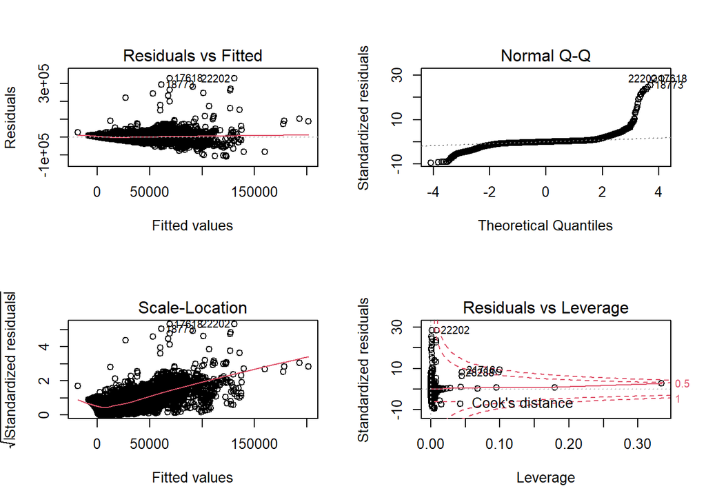

```r
par(mfrow=c(2,2))
plot(md3)
```

```r
test$preis_pred <- predict(md3, test)
rSquared(test$preis, test$preis-test$preis_pred)
```

```
##           [,1]
## [1,] 0.7468329
```

Just to try out:

```r
# Model with the highest r2 Score:
model5 <- lm(log10(preis)~poly(Alter,8)+marke+poly(ps,8)+poly(km,8),train)
summary(model5)
```

```
##
## Call:
## lm(formula = log10(preis) ~ poly(Alter, 8) + marke + poly(ps,
##     8) + poly(km, 8), data = train)
##
## Residuals:
##      Min       1Q   Median       3Q      Max
## -1.31038 -0.05769 -0.00163  0.05576  1.52302
##
## Coefficients:
##                       Estimate Std. Error  t value Pr(>|t|)
## (Intercept)           4.030290   0.061528   65.504  < 2e-16 ***
## poly(Alter, 8)1     -28.151043   0.202872 -138.762  < 2e-16 ***
## poly(Alter, 8)2      -4.808390   0.161595  -29.756  < 2e-16 ***
## poly(Alter, 8)3       0.561269   0.148316    3.784 0.000155 ***
## poly(Alter, 8)4       1.612835   0.139303   11.578  < 2e-16 ***
## poly(Alter, 8)5       1.448380   0.129295   11.202  < 2e-16 ***
## poly(Alter, 8)6       1.399244   0.125277   11.169  < 2e-16 ***
## poly(Alter, 8)7      -0.656656   0.125250   -5.243 1.60e-07 ***
## poly(Alter, 8)8      -0.382994   0.124637   -3.073 0.002123 **
## markeAlfa Romeo      -0.229453   0.066878   -3.431 0.000603 ***
## markeAlpina           0.345559   0.137572    2.512 0.012017 *
## markeAston Martin     0.400441   0.094151    4.253 2.12e-05 ***
## markeAudi             0.035107   0.061579    0.570 0.568614
## markeBentley         -0.252475   0.082830   -3.048 0.002306 **
## markeBMW             -0.003544   0.061578   -0.058 0.954107
## markeChevrolet       -0.219683   0.067119   -3.273 0.001066 **
## markeChrysler        -0.259798   0.073998   -3.511 0.000447 ***
## markeCitroen         -0.106042   0.061665   -1.720 0.085509 .
## markeCorvette         0.313465   0.137568    2.279 0.022698 *
## markeCupra           -0.207728   0.087168   -2.383 0.017176 *
## markeDacia           -0.132560   0.066446   -1.995 0.046054 *
## markeDaewoo          -0.750576   0.087076   -8.620  < 2e-16 ***
## markeDaihatsu        -0.225841   0.071071   -3.178 0.001486 **
## markeDodge           -0.026404   0.137567   -0.192 0.847792
## markeDS Automobiles  -0.073609   0.137459   -0.535 0.592312
## markeFerrari          0.627246   0.079576    7.882 3.35e-15 ***
## markeFiat            -0.081570   0.061657   -1.323 0.185861
## markeFord            -0.109159   0.061634   -1.771 0.076561 .
## markeHonda           -0.018146   0.067126   -0.270 0.786917
```

[output cut: 39 more lines]

```
## poly(ps, 8)8         -0.293257   0.123815   -2.368 0.017869 *
## poly(km, 8)1        -18.638281   0.197567  -94.339  < 2e-16 ***
## poly(km, 8)2          2.224406   0.152009   14.633  < 2e-16 ***
## poly(km, 8)3          1.593471   0.140523   11.340  < 2e-16 ***
## poly(km, 8)4         -0.580862   0.138015   -4.209 2.58e-05 ***
## poly(km, 8)5         -0.415797   0.134133   -3.100 0.001938 **
## poly(km, 8)6          0.645064   0.130689    4.936 8.03e-07 ***
## poly(km, 8)7         -0.258247   0.128161   -2.015 0.043913 *
## poly(km, 8)8          0.279884   0.126298    2.216 0.026698 *
## ---
## Signif. codes:  0 '***' 0.001 '**' 0.01 '*' 0.05 '.' 0.1 ' ' 1
##
## Residual standard error: 0.1229 on 23443 degrees of freedom
## Multiple R-squared:  0.9146, Adjusted R-squared:  0.9143
## F-statistic:  3304 on 76 and 23443 DF,  p-value: < 2.2e-16
```